# Sprocket Central Pty Ltd - Medium Size Bikes & Cycling Accessories Organisation's Transactions Data Based Cohort Analysis

## By Ahmed Mohamed Sayed

### **What is Cohort and Cohort Analysis?**

- A cohort is a collection of users who have something in common. A traditional cohort, for example, divides people by the week or month of which they were first acquired. When referring to non-time-dependent groupings, the term segment is often used instead of cohort.
- Cohort analysis is a descriptive analytics technique in cohort analysis. Customers are divided into mutually exclusive cohorts, which are then tracked over time.
- Vanity indicators don’t offer the same level of perspective as cohort research. It aids in the deeper interpretation of high-level patterns by supplying metrics around the product and consumer lifecycle.

### **Generally, there are two major types of Cohort**:

1- **Time cohorts:** Customers who signed up for a product or service during a particular time frame "the basis of the acquisition date".

2- **Behavior cohorts:** Customers who purchased a product or subscribed to service in the past.

**However, we will be performing Cohort Analysis based on Time. Customers will be divided into acquisition cohorts depending on the month of their first purchase. The cohort index would then be assigned to each of the customer’s purchases, which will represent the number of months since the first transaction**.

### **Objectives**:

1- Finding the percentage of active customers compared to the total number of customers after each month.

2- Interpret the Customer retention rate **(CRR)**.

### **Cohort Analysis Steps**:

### 1-Data Loading, Cleaning & Wrangling:

- Importing the needed libraries, loading data & check any missing values (numerical or categorical) and fill them.

|  | transaction_id | product_id | customer_id | transaction_date | online_order | order_status | brand | product_line | product_class | product_size | list_price | standard_cost | product_first_sold_date |
| --- | --- | --- | --- | --- | --- | --- | --- | --- | --- | --- | --- | --- | --- |
| 0 | 1 | 2 | 2950 | 2017-02-25 | 0.0 | Approved | Solex | Standard | medium | medium | 71.49 | 53.62 | 41245.0 |
| 1 | 2 | 3 | 3120 | 2017-05-21 | 1.0 | Approved | Trek Bicycles | Standard | medium | large | 2091.47 | 388.92 | 41701.0 |
| 2 | 3 | 37 | 402 | 2017-10-16 | 0.0 | Approved | OHM Cycles | Standard | low | medium | 1793.43 | 248.82 | 36361.0 |
| 3 | 4 | 88 | 3135 | 2017-08-31 | 0.0 | Approved | Norco Bicycles | Standard | medium | medium | 1198.46 | 381.10 | 36145.0 |
| 4 | 5 | 78 | 787 | 2017-10-01 | 1.0 | Approved | Giant Bicycles | Standard | medium | large | 1765.30 | 709.48 | 42226.0 |

### 2-Defining Cohorts :

#### **Step 1**:

- Extract transaction year & month from **transaction_date** column to identify month for every transaction.
- Grouping customers & transaction month then selecting the first transaction for each customer so that we could assign the acquisition month for each.

  **The result is assigning aquisition month cohort for every customer**

#### **Step 2**:

- Extract transaction year & month
- Extract cohort year & month.
- Calculate Difference in years & months to create cohort index (Diff between any transaction and the first transaction for each customer) .

**The result is creating a cohort index column that represents the month of each customers' transactions among months.**

#### **Step 3**:

- Calculate Daily Active Users **(DAU)** from each cohort.
- Counting unique users from each cohort.
- Create Dataframe **(pivot table)** with CohortMonth in the **rows**, CohortIndex in the **columns**, and customer_id counts as **values**.

**The result is to create the main table for calculating CRR & other metrics.**

| cohort_index Cohortmonth | 1 | 2 | 3 | 4 | 5 | 6 | 7 | 8 | 9 | 10 | 11 | 12 |
| --- | --- | --- | --- | --- | --- | --- | --- | --- | --- | --- | --- | --- |
| 2017-01-01 | 1354.0 | 486.0 | 508.0 | 509.0 | 502.0 | 483.0 | 518.0 | 529.0 | 500.0 | 531.0 | 497.0 | 516.0 |
| 2017-02-01 | 800.0 | 325.0 | 298.0 | 313.0 | 288.0 | 298.0 | 308.0 | 281.0 | 329.0 | 308.0 | 296.0 | NaN |
| 2017-03-01 | 484.0 | 167.0 | 174.0 | 167.0 | 182.0 | 184.0 | 172.0 | 212.0 | 189.0 | 181.0 | NaN | NaN |
| 2017-04-01 | 336.0 | 111.0 | 121.0 | 153.0 | 143.0 | 121.0 | 142.0 | 126.0 | 132.0 | NaN | NaN | NaN |
| 2017-05-01 | 210.0 | 85.0 | 81.0 | 87.0 | 71.0 | 74.0 | 73.0 | 81.0 | NaN | NaN | NaN | NaN |
| 2017-06-01 | 122.0 | 45.0 | 44.0 | 47.0 | 46.0 | 46.0 | 53.0 | NaN | NaN | NaN | NaN | NaN |
| 2017-07-01 | 77.0 | 26.0 | 29.0 | 32.0 | 37.0 | 24.0 | NaN | NaN | NaN | NaN | NaN | NaN |
| 2017-08-01 | 51.0 | 19.0 | 21.0 | 17.0 | 13.0 | NaN | NaN | NaN | NaN | NaN | NaN | NaN |
| 2017-09-01 | 23.0 | 7.0 | 7.0 | 9.0 | NaN | NaN | NaN | NaN | NaN | NaN | NaN | NaN |
| 2017-10-01 | 20.0 | 6.0 | 8.0 | NaN | NaN | NaN | NaN | NaN | NaN | NaN | NaN | NaN |
| 2017-11-01 | 13.0 | 5.0 | NaN | NaN | NaN | NaN | NaN | NaN | NaN | NaN | NaN | NaN |
| 2017-12-01 | 4.0 | NaN | NaN | NaN | NaN | NaN | NaN | NaN | NaN | NaN | NaN | NaN |

### 3-Caclulating Customer Retention Rate (CRR) :

###### CRR measures how many customers from each of the cohort have returned in the subsequent months.

- Using the dataframe called cohort_counts we will select the First columns(equals to total number of customer in cohorts)
- Calculate the ratio of how many of these customers came back in the subsequent months.

| cohort_index Cohortmonth | 1 | 2 | 3 | 4 | 5 | 6 | 7 | 8 | 9 | 10 | 11 | 12 |
| --- | --- | --- | --- | --- | --- | --- | --- | --- | --- | --- | --- | --- |
| 2017-01-01 | 100.0 | 36.0 | 38.0 | 38.0 | 37.0 | 36.0 | 38.0 | 39.0 | 37.0 | 39.0 | 37.0 | 38.0 |
| 2017-02-01 | 100.0 | 41.0 | 37.0 | 39.0 | 36.0 | 37.0 | 38.0 | 35.0 | 41.0 | 38.0 | 37.0 | NaN |
| 2017-03-01 | 100.0 | 35.0 | 36.0 | 35.0 | 38.0 | 38.0 | 36.0 | 44.0 | 39.0 | 37.0 | NaN | NaN |
| 2017-04-01 | 100.0 | 33.0 | 36.0 | 46.0 | 43.0 | 36.0 | 42.0 | 38.0 | 39.0 | NaN | NaN | NaN |
| 2017-05-01 | 100.0 | 40.0 | 39.0 | 41.0 | 34.0 | 35.0 | 35.0 | 39.0 | NaN | NaN | NaN | NaN |
| 2017-06-01 | 100.0 | 37.0 | 36.0 | 39.0 | 38.0 | 38.0 | 43.0 | NaN | NaN | NaN | NaN | NaN |
| 2017-07-01 | 100.0 | 34.0 | 38.0 | 42.0 | 48.0 | 31.0 | NaN | NaN | NaN | NaN | NaN | NaN |
| 2017-08-01 | 100.0 | 37.0 | 41.0 | 33.0 | 25.0 | NaN | NaN | NaN | NaN | NaN | NaN | NaN |
| 2017-09-01 | 100.0 | 30.0 | 30.0 | 39.0 | NaN | NaN | NaN | NaN | NaN | NaN | NaN | NaN |
| 2017-10-01 | 100.0 | 30.0 | 40.0 | NaN | NaN | NaN | NaN | NaN | NaN | NaN | NaN | NaN |
| 2017-11-01 | 100.0 | 38.0 | NaN | NaN | NaN | NaN | NaN | NaN | NaN | NaN | NaN | NaN |
| 2017-12-01 | 100.0 | NaN | NaN | NaN | NaN | NaN | NaN | NaN | NaN | NaN | NaN | NaN |

### 4-Visualizing Customer Retention Rate **(CRR)**:

###### Heatmap is the best visual type for presenting CRR

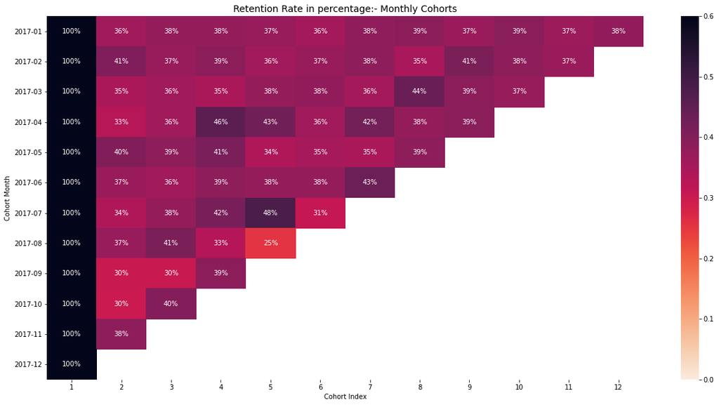

### 5- Interpreting the **CRR**:

- **100%** value in all cells in column 1 represents that this was the month when customer signed up or did their first transaction and have rate of 100% activity.
- The highlighted value of 48% means that **48%** of the cohort that signed in **July 2017** were active **5 months** later.

[figure not shown]